# Data exploration: the importance of plotting

## Simple example

Consider that you have two variables `x` and `y`.

```r
x <- 1:100
y <-  20 * x - 0.2 * x^2 + rnorm(100, 0, 30)
```

You are interested to understand if `x` explains variation in `y`. How will you approach this?

## Should you build a linear model first or plot the variables first and visually explore?

Let's examine the outcome and inference if **we do not visually examine our data** and only rely on regression modeling.

```r
mod_lin <- lm(y ~ x)
summary(mod_lin)
```

```
##
## Call:
## lm(formula = y ~ x)
##
## Residuals:
##     Min      1Q  Median      3Q     Max
## -378.48 -108.54   32.55  126.13  180.80
##
## Coefficients:
##             Estimate Std. Error t value Pr(>|t|)
## (Intercept) 344.7734    29.8143  11.564   <2e-16 ***
## x            -0.2913     0.5126  -0.568    0.571
## ---
## Signif. codes:  0 '***' 0.001 '**' 0.01 '*' 0.05 '.' 0.1 ' ' 1
##
## Residual standard error: 148 on 98 degrees of freedom
## Multiple R-squared:  0.003285,   Adjusted R-squared:  -0.006886
## F-statistic: 0.3229 on 1 and 98 DF,  p-value: 0.5711
```

The above model summary table would lead us to believe that there is no relationship between `x` and `y` which we know is false because we created the variables above.

## Why is it our regression table leading us to an incorrect inference?

Because our model is systematically mis-representing the functional form of the relationship between `x` and `y` which we defined to be a quadratic relationship. This would have been obvious if we first graphed `y` and `x`

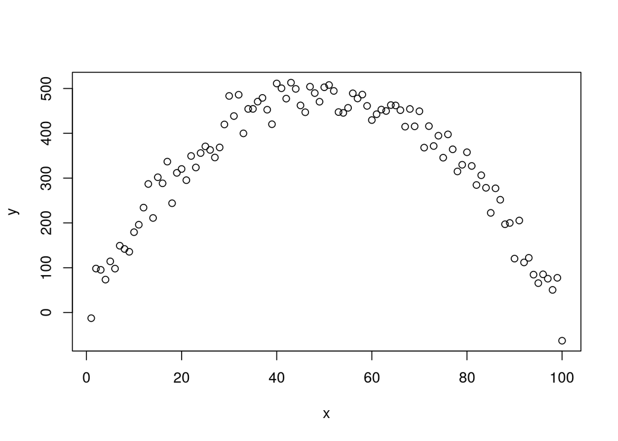

```r
plot(y ~ x)
```

This simple step would indicate to us that `y` is not just a linear function of `x` but it is a quadratic function, such that a more appropriate model is:

```r
mod_quad <- lm(y ~ x + I(x^2))
summary(mod_quad)
```

```
##
## Call:
## lm(formula = y ~ x + I(x^2))
##
## Residuals:
##     Min      1Q  Median      3Q     Max
## -66.837 -22.635   3.558  17.125  67.744
##
## Coefficients:
##             Estimate Std. Error t value Pr(>|t|)
## (Intercept) 13.85923    8.94040    1.55    0.124
## x           19.17426    0.40860   46.93   <2e-16 ***
## I(x^2)      -0.19273    0.00392  -49.17   <2e-16 ***
## ---
## Signif. codes:  0 '***' 0.001 '**' 0.01 '*' 0.05 '.' 0.1 ' ' 1
##
## Residual standard error: 29.21 on 97 degrees of freedom
## Multiple R-squared:  0.9616, Adjusted R-squared:  0.9608
## F-statistic:  1213 on 2 and 97 DF,  p-value: < 2.2e-16
```

To further articulate why the regression only approach failed we should overlay the models and the data. Unfortunately, this critical step is often overlooked.

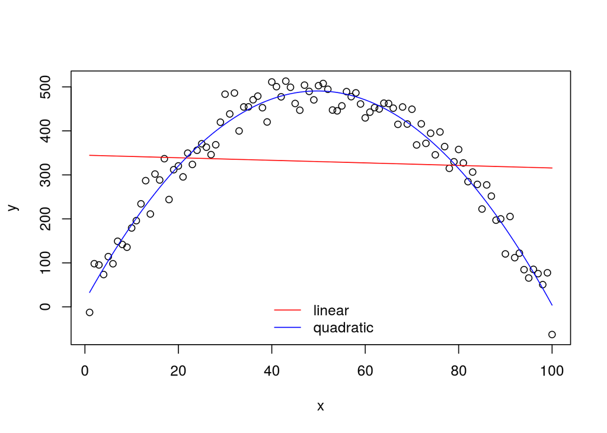

```r
plot(y ~ x)
lines(x, predict(mod_lin), col='red')
lines(x, predict(mod_quad), col='blue')
legend('bottom', c('linear', 'quadratic'), col=c('red', 'blue'), lty=1, bty='n')
```

Here we just looked at two variables so it may be obvious that graphing them is wise, but even in multivariate scenarios where a graphical exploration may be more tedious it can still be very helpful and illuminating prior to model fitting.